# Лабораторная работа 5. Основы анализа данных NumPy и Matplotlib.

# Часть 1. NumPy

При решении научных задач с помощью численных методов зачастую приходится иметь дело с большими массивами данных в виде массивов и матриц. Стандартные средства Python (например, использование списков для хранения данных и прямой перебор элементов с помощью циклов) плохо подходят для таких задач, так как будут работать крайне медленно, в отличие от программ на компилируемых языках (Fortran, С). Пакет NumPy (http://www.numpy.org/) — это основной пакет, используемый в научных вычислениях в Python. NumPy предназначен для эффективной работы с многомерными массивами, в том числе для эффективного применения математических операций к массивам и матрицам и их модификации без прямого перечисления элементов массивов. Помимо этого NumPy обладает и другими возможностями — линейная алгебра, удобный ввод/вывод в файлы, моделирование случайных величин, быстрое преобразование Фурье, объединение программ на Fortran и С и другое (подробнее см. оф. сайт), поэтому важно изучить возможности данной библиотеки как можно лучше.

1. Внимательно изучите следующий урок по NumPy: http://scipy.github.io/old-wiki/pages/Tentative_NumPy_Tutorial.
2. Изучите официальное руководство пользователя https://docs.scipy.org/doc/numpy/user/.
3. Внимательно изучите Reference Guide (полное описание всех функций) https://docs.scipy.org/doc/numpy/reference/, именно в нем перечислены все возможности NumPy, этой ссылкой придется регулярно пользоваться.

Выполните следующие задания (их много, но каждое занимает одну или несколько строк) средствами NumPy (и без использования циклов!)

Импортируйте пакет numpy под именем nр

```python
import numpy as np
from numpy  import *
```

Создайте вектор из 10 элементов, заполненный 0, пятый элемент которого равен 1.

```python
n1=zeros((1,10))
n1[0][4]=1
n1
```

```
array([[0., 0., 0., 0., 1., 0., 0., 0., 0., 0.]])
```

Создайте матрицу 3 на 3 со значениями от 0 до 8.

```python
a = arange(9).reshape(3, 3)
a
```

```
array([[0, 1, 2],
       [3, 4, 5],
       [6, 7, 8]])
```

Найдите индексы ненулевых элементов вектора [1,2,0,0,4,0].

```python
a2 = array( [1,2,0,0,4,0] )
counter = 0
for i in a2 :
    if(i!=0): print(counter)
    counter+=1
```

```
0
1
4
```

```python
a3=ones((3,3))
a3
```

```
array([[1., 1., 1.],
       [1., 1., 1.],
       [1., 1., 1.]])
```

Создайте массив 10x10x10 из случайных чисел.

```python
a4=random.random((10,10,10))
a4
```

[output not shown]

[output cut: 154 more lines]

[output not shown]

Создайте матрицу 8 на 8, заполненную 0 и 1 в шахматном порядке.

```python
a5 = zeros(64).reshape(8, 8)
counter1 = 0
counter2 = 0
for i in range(0, 8):
    for j in range(0, 8):
        if(counter1 % 2 ==0):
            if(counter2 % 2 ==0):
                a5[i][j] = 1
        else:
            if(counter2 % 2 !=0):
                a5[i][j] = 1
        counter2 +=1
    counter1 += 1
    counter2=0
a5
```

```
array([[1., 0., 1., 0., 1., 0., 1., 0.],
       [0., 1., 0., 1., 0., 1., 0., 1.],
       [1., 0., 1., 0., 1., 0., 1., 0.],
       [0., 1., 0., 1., 0., 1., 0., 1.],
       [1., 0., 1., 0., 1., 0., 1., 0.],
       [0., 1., 0., 1., 0., 1., 0., 1.],
       [1., 0., 1., 0., 1., 0., 1., 0.],
       [0., 1., 0., 1., 0., 1., 0., 1.]])
```

```python
m1 = [ [5, 6, 7],[2, 3, 4]]

m2 = [[2, 5, 8, 11],[3, 6, 9, 12],[1, 4, 7, 10]]

m3 = [ [ sum(map(lambda x: x[0] * x[1], zip(m1[i], [c[j] for c in m2]))) for j in range(len(m2[0])) ] for i in range(len(m1)) ]

for res in m3:
    print(res)
```

```
[35, 89, 143, 197]
[17, 44, 71, 98]
```

Создайте матрицу, в каждом ряду которой стоят числа от 0 до 8 (используйте сложение матрицы с вектором).

```python
a7=np.zeros((3,9))
v1=np.array([0,1,2,3,4,5,6,7,8])
anew=a7+v1
anew
```

```
array([[0., 1., 2., 3., 4., 5., 6., 7., 8.],
       [0., 1., 2., 3., 4., 5., 6., 7., 8.],
       [0., 1., 2., 3., 4., 5., 6., 7., 8.]])
```

Создайте вектор длины 1000. Найдите среднее (арифметическое) значение из этих элементов.

```python
a8=np.random.random((1,1000))
sum=0
for i in range(0,len(a8[0])-1):
    sum+=a8[0][i]
print(sum/1000)
```

```
0.5078050690601144
```

## Часть 2. Matplotlib

Matplotlib (http://matplotlib.org/index.html) — это библиотека для создания графиков в Python. Matplotlib позволяет строить графики любой сложности типографского качества, которые можно вставить в статью. Подробнее о возможностях см. http://matplotlib.org/users/ intro.html. Matplotlib — большой и сложный инструмент, но на прак¬тике в научных вычислениях часто пользуются частью библиотеки matplotlib .pyplot, которая имитирует построение графиков в стиле MATLAB. В качестве достаточно полного введения можно прочитать http://matplotlib.org/users/index.html.

На практике бывает очень трудно помнить все возможности Matplotlib, поэтому часто используют галереи готовых примеров, а потом модифи-цируют их под свои нужды. Примеры таких подборок можно найти по следующим ссылкам:

• http://matplotlib.org/gallery.html • http://matplotlib.org/examples/index.html • http://wiki.scipy.org/Cookbook/Matplotlib/

Еще материалы.

1. Введение http://matplotlib.org/users/pyplot_tutorial.html
2. Введение 2 http://www.loria.fr/~rougier/teaching/matplotlib/. Изучите, как создавать графики разных типов http://www.loria.fr/~rougier/teaching/matplotlib/#other-types-of-plots.
3. Использование текста в подписях и т.д. http://matplotlib.org/users/text_intro.html.
4. Использование математического текста http://matplotlib.org/users/mathtext.html.
5. Создание легенды http://matplotlib.org/users/legend_guide.html.
6. Интерактивное использование Matplotlib http://matplotlib.org/users/shell.html (этот пример можно использовать не только в командной строке, но и в коде для наблюдения за изменением графиков в ходе выполнения программы).

```python
import matplotlib as mp
import matplotlib.pyplot as plt
```

Постройте поточечный график функции. Сгенерируйте два массива для этого. Один со значениями по возрастанию (для X), второй со случайными значениями (для Y).

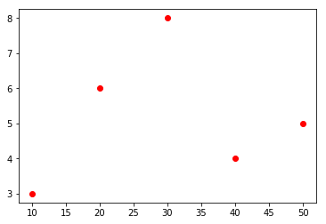

```python
X=([10,20,30,40,50])
Y=([3,6,8,4,5])
plt.plot(X,Y, "ro")
plt.show()
```

Выберите тригонометрическую функцию $T(x)$, выберите полином $P(x)$. Постройте график функции $T(x)P(x)$.

К графику добавьте: обозначение оси абсцисс, обозначение оси ординат, название графика, вставка легенды (текста в label).

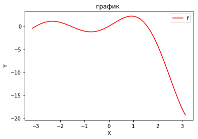

```python
X = np.linspace(-np.pi, np.pi, 256, endpoint=True)
Tx=np.cos(X)
def Px(X):
    return X**2+3*X
f=Tx*Px(X)
plt.plot(X,f, "r")
plt.title('график ')
plt.xlabel('X')
plt.ylabel('Y')
plt.legend("f")
plt.show()
```

Измените цвет графика на Ваш любимый.

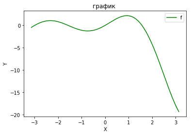

```python
plt.plot(X,f, "g")
plt.title('график ')
plt.xlabel('X')
plt.ylabel('Y')
plt.legend("f")
plt.show()
```

Постройте несколько квивых. Первая - цвет красный, сплошная, вторая - цвет синий, штрих-пунктир.

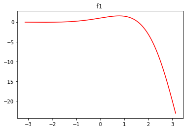

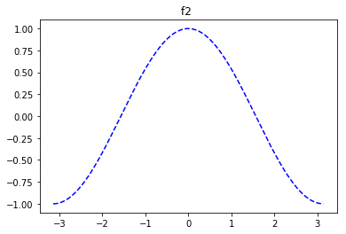

```python
def f1(X):
    return np.exp(X) * np.cos(X)
def f2(X):
    return np.cos(X)
plt.title('f1 ')
plt.plot(X,f1(X), "r")
plt.show()
plt.title('f2 ')
plt.plot(X,f2(X), "b--")
plt.show()
```

Постройте теже графики, только для первого добавьте маркеры из красных треугольников, для второго синие круглые маркеры.

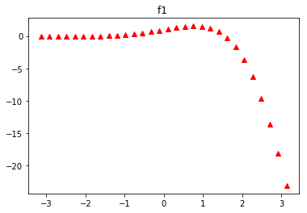

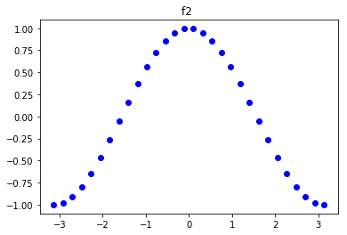

```python
X = np.linspace(-np.pi, np.pi, 30, endpoint=True)
plt.title('f1 ')
plt.plot(X,f1(X), "r^")
plt.show()
plt.title('f2 ')
plt.plot(X,f2(X), "bo")
plt.show()
```

# Часть 3. OpenCV

Прочитайте картинку используя opencv

```python
import cv2

img = cv2.imread('picture.png')
cv2.imshow('image',img)
cv2.waitKey(0)
cv2.destroyAllWindows()
```

Сделайте ее черно-белой

```python
gray_image = cv2.cvtColor(img, cv2.COLOR_BGR2GRAY)
cv2.imshow('image',gray_image)
cv2.waitKey(0)
cv2.destroyAllWindows()
```

Измените размер на 300x300

```python
resize_img = cv2.resize(img  , (300 , 300))
cv2.imshow('image' , resize_img)
cv2.waitKey(0)
cv2.destroyAllWindows()
```

Разбейте ее на 2 картинки. Сохраните.

```python
width, height, channels=img.shape
slice1=img[0:int(height/2),0:int(width)]
cv2.imshow('image' , slice1)
cv2.waitKey(0)
cv2.destroyAllWindows()
slice2=img[int(height/2):height,0:int(width)]
cv2.imshow('image' , slice2)
cv2.waitKey(0)
cv2.destroyAllWindows()
cv2.imwrite("picture1.png", slice1)
cv2.imwrite("picture2.png", slice2)
```

```
True
```

Прочитайте 2 картинки и склейте.

```python
im1=cv2.imread("picture1.png")
im2=cv2.imread("picture2.png")
imgnew=np.concatenate((im1, im2), axis=0)
cv2.imwrite('res.png', imgnew)
cv2.imshow('image' , imgnew)
cv2.waitKey(0)
cv2.destroyAllWindows()
```